# Comparing the CMIP5 suite of climate models to observed global temperatures.

## Reproducing Michaels and Knappenberger (M&K’s) key figure

Let’s start by readying the necessary packages that we’ll be using to analyse the data.

```r
rm(list=ls()) ## Clear data

require(readr) ## For reading in data
require(tidyr) ## For data tidying (gather, etc.)
require(dplyr) ## For data munging and manipulation (filter, mutate, etc.)
require(quantreg) ## For efficient recursive regression estimates
require(Hmisc) ## For additional minor ticks in plot
require(alr3) ## For calculating confidence intervals for regression estimates
```

Next, we read in the data. Note that I have already uploaded the CMIP5 ensemble data to this GitHub repository, since that saves you from having to go through the [Climate Explorer](http://climexp.knmi.nl/) interface.[^1] The HadCRUT4 data, on the other hand, is already in a convenient form and so we’ll download this data directly from the Met Office website.

```r
### CMIP5 ensemble ###
cmip5 <- read_csv("cmip5.csv")

### HadCRUT4 ###
had <- read_table("http://www.metoffice.gov.uk/hadobs/hadcrut4/data/current/time_series/HadCRUT.4.4.0.0.annual_ns_avg.txt",
                         col_names = c("Year", "HadCRUT4", 3:12)
                         )
```

Now we need to tidy the data and get the annual temperature means. We’ll be using the extremely useful `tidyr` and `dplyr` packages from [Hadley](http://had.co.nz/), and also be making liberal use of the awesome pipe operator (`%>%`).

```r
## First decide on dates for the recursive sample.
end_year <- c(2014, 2005, 2000)[1] ## M&K use 2014. This is the fixed point for the recursive estimates.
start_year <- end_year - 63 ## To coincide with's M&K's choice of 1951 when using 2014 as an end date.

### CMIP5 Ensemble ###
cmip5 <-
  cmip5 %>%
  filter(Year <= end_year)
## Already cleaned. See: https://github.com/grantmcdermott/cmip5-models/blob/master/cmip5_download/cmip5_download.md

### HadCRUT4 ###
had <-
  had %>%
  select(Year, HadCRUT4) %>%
  filter(Year >= cmip5$Year[1] & Year <= end_year) %>%
  group_by(Year) %>%
  summarise(HadCRUT4 = mean(HadCRUT4)) %>% ## Collapse into all annual averages
  gather(Series, Temp, HadCRUT4)
```

Using the annual data, we can now calculate the trends and recursive estimates for both the CMIP5 ensemble and the observed (i.e. HadCRUT4) temperature data. Note that the CMIP5 recursive regressions are grouped by model and that we multiply the end result by 10 to obtain the decadal trend, so as to be consistent with M&K’s paper.

```r
### CMIP5 ensemble ###
cmip5_trend <-
  cmip5 %>%
  group_by(Model) %>%
  arrange(desc(Year)) %>%
  mutate(Length = max(Year) - Year + 1) %>%
  mutate(Time = Year - min(Year) + 1) %>%
  filter(Year >= start_year) %>%
  mutate(Trend = 10 * as.numeric(lm.fit.recursive(as.matrix(Time), Temp, int = T)[2, ]))

## Summarise the indiv. model results i.t.o. ensemble mean and C.I.s.
cmip5_trend_summ <-
  cmip5_trend %>%
  group_by(Year) %>%
  summarise(Trend_mean = mean(Trend),
            Trend_025 = quantile(Trend, p = 0.025),
            Trend_05 = quantile(Trend, p = 0.05),
            Trend_95 = quantile(Trend, p = 0.95),
            Trend_975 = quantile(Trend, p = 0.975)
            ) %>%
  arrange(desc(Year)) %>%
  mutate(Length = max(Year) - Year + 1) %>%
  filter(Length >= 10)

### HadCRUT4 ###
had_trend <-
  had %>%
  arrange(desc(Year)) %>%
  mutate(Length = max(Year) - Year + 1) %>%
  mutate(Time = Year - min(Year) + 1) %>%
  filter(Year >= start_year) %>%
  mutate(Trend = 10 * as.numeric(lm.fit.recursive(as.matrix(Time), Temp, int = T)[2, ]) ) %>%
  filter(Length >= 10)
```

Nearly there. We now combine our recursive trend estimates in a single figure that matches [**this one**](http://object.cato.org/sites/cato.org/files/wp-content/uploads/gsr_12_18_14_fig2.png) from M&K. I’d normally do this in `ggplot2`, but I’m using R’s base plotting features (with a number of little tweaks) to try and get it looking as close to M&K’s original as possible.

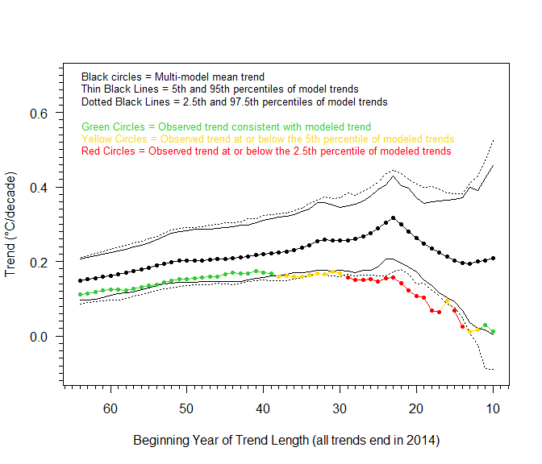

```r
par(las = 1) # Rotate y-axis labels sideways
plot(cmip5_trend_summ$Length, cmip5_trend_summ$Trend_mean,
     type="l", lwd = 1.5,
     main = "",
     xlab = paste0("Beginning Year of Trend Length (all trends end in ", end_year, ")"),
     ylab = "Trend (°C/decade)",
     xlim = rev(range(cmip5_trend_summ$Length)),
     ylim = c(-.1, .7),
     cex = 0.8
     )
minor.tick(nx = 10, ny = 10) ## Optional
points(cmip5_trend_summ$Length, cmip5_trend_summ$Trend_mean, pch = 20)
lines(cmip5_trend_summ$Length, cmip5_trend_summ$Trend_025, lwd = 1, lty = 3)
lines(cmip5_trend_summ$Length, cmip5_trend_summ$Trend_05, lwd = 1, lty = 1)
lines(cmip5_trend_summ$Length, cmip5_trend_summ$Trend_95, lwd = 1, lty = 1)
lines(cmip5_trend_summ$Length, cmip5_trend_summ$Trend_975, lwd = 1, lty = 3)
lines(had_trend$Length, had_trend$Trend, col = "limegreen", lwd = 1.5, lty = 1)
points(had_trend$Length, had_trend$Trend, col = "limegreen", pch = 20)
legend("topleft",
       c("Black circles = Multi-model mean trend",
         "Thin Black Lines = 5th and 95th percentiles of model trends",
         "Dotted Black Lines = 2.5th and 97.5th percentiles of model trends",
         "",
         "Green Circles = Observed trend consistent with modeled trend",
         "Yellow Circles = Observed trend at or below the 5th percentile of modeled trends",
         "Red Circles = Observed trend at or below the 2.5th percentile of modeled trends"
         ),
       text.col = c("black", "black", "black", "black", "limegreen", "gold", "red"),
       bty = "n", cex = 0.8)
## Some additional lines of code to match colour coding of M&K.
had_05 <- had_trend$Trend < cmip5_trend_summ$Trend_05
had_025 <- had_trend$Trend < cmip5_trend_summ$Trend_025
had.col <- ifelse(had_025, "red", ifelse(had_05, "gold", "limegreen"))
had_05_line <- ifelse(had_05, had_trend$Trend, NA)
had_025_line <- ifelse(had_025, had_trend$Trend, NA)
lines(had_trend$Length, had_05_line, col = "gold", lwd=1.5, lty = 1)
lines(had_trend$Length, had_025_line, col = "red", lwd = 1.5, lty = 1)
points(had_trend$Length, had_trend$Trend, col = had.col, pch = 20)
```

Good news: We have successfully replicated M&K’s [key figure](http://object.cato.org/sites/cato.org/files/wp-content/uploads/gsr_12_18_14_fig2.png)! Now comes the interesting part, however, because M&K use this figure [to claim](http://www.cato.org/blog/agu-2014-quantifying-lack-consistency-between-climate-model-projections-observations-evolution) that: *“[A]t the global scale, this suite of climate models has failed. Treating them as mathematical hypotheses, which they are, means that it is the duty of scientists to reject their predictions in lieu of those with a lower climate sensitivity.”*

As, we’re about to see, neither claim makes much sense at all because M&K haven’t actually done any proper hypothesis testing… Indeed, they have completely forgotten to calculate confidence intervals!

## Criticism #1: Missing confidence intervals

The point about missing confidence intervals is really important. The “spread” that we see in the above graph is just a pseudo-interval generated by the full CMIP5 ensemble (i.e. the individual trend means across all 108 climate models). In other words, it is a measure of *model* uncertainty, not *statistical* uncertainty. We haven’t said anything yet about the confidence intervals attached to each trend estimate, $\hat{\beta_1}$. And, as any first-year econometrics student will tell you, regression coefficients must come with standard errors and implied confidence intervals. Indeed, accounting for these uncertainties is primarily what hypothesis testing is all about: Can we confidently rule out that a parameter of interest doesn’t overlap with some value or range? Absent these uncertainty measures, one cannot talk meaningfully about rejecting a hypothesis.

With these points in mind, let us add the 95% error bars to each of the trend estimates for the observed HadCRUT4 temperature data. First, we need to calculate them. A small technical point is that the `lm.fit.recursive` function from the `quantreg` package (which we used to get the recursive regression coefficient means earlier) doesn’t actually produce standard errors or confidence intervals. Nonetheless, we are able to obtain these manually by calling a loop of sequential (i.e recursive) regressions using the `do()` function in combination with various `apply` functions to extract the relevant parameters. We could also have used a standard “for loop”“, but this way is much more efficient.

```r
had_rec <-
  had %>%
  arrange(desc(Year)) %>%
  mutate(Length = max(Year) - Year + 1) %>%
  mutate(Time = Year - min(Year) + 1) %>%
  filter(Year >= start_year) %>%
  do(mod = lapply(seq(10, nrow(.)), function(x) lm(Temp ~ Time, data = .[1:x, ])))

## Extract recursive trend (already calculated earlier with the "lm.fit.recursive" call) and 95% C.I.
## Note: Again, we multiply by ten to match the decadal time scale.
trend_rec <- 10*unlist(sapply(1:nrow(had_trend), function(j) had_rec$mod[[1]][[j]]$coefficients["Time"])) ## Already calculated, but just illustrating the point.
ci_rec <- 10*unlist(sapply( 1:nrow(had_trend), function(j) confint(had_rec$mod[[1]][[j]], level = .95)["Time",]))
```

Now we add these confidence intervals to the previous plot.

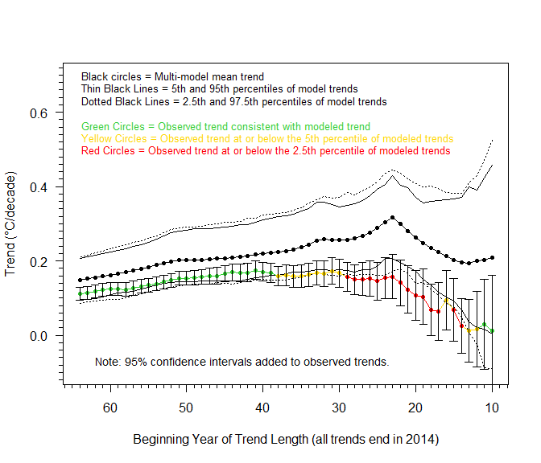

```r
## Add to plot
arrows(10:max(had_trend$Length), ci_rec[1,], 10:max(had_trend$Length), ci_rec[2, ], length = 0.05, angle = 90, code=3)
text(62, -0.08, "Note: 95% confidence intervals added to observed trends.",
     adj = c(0,0), cex = 0.85)
```

## Criticism #2: Fixed starting date (recursive vs rolling regressions)

My second major criticism of M&K’s study is their choice of recursive regression model and fixed starting point. The starting point for all of these regressions is 2014, which just so happens to be a year where observed temperatures were unusually lower than the model estimates (i.e. compared to earlier years). In other words, M&K are anchoring their results in a way that distorts the relative trends along the remainder of the recursive series.

Now, you may argue that it makes sense to use the most recent year as your starting point. However, the principle remains: Privileging observations from any particular year is going to give you misleading results in climate research, where the long-term is what really matters. Rather than a recursive regression, I would therefore argue that a rolling regression offers a much better way of investigating the performance of climate models. Another alternative is to stick with recursive regressions, but to vary the starting date. This is what I have done in the figures below, using 2005 and then 2000 as the new fixed point. (For the sake of comparison, I keep the maximum trend length the same, so each of these goes a little further back in time.) The effect on the relative trend slopes – and therefore the agreement between climate models and observations – is clear to see.

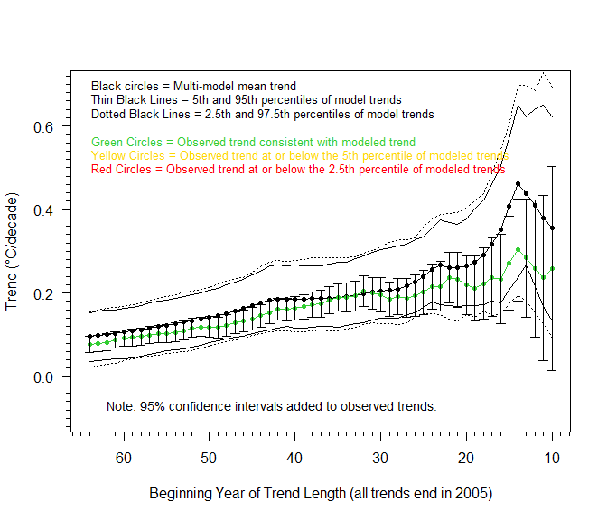

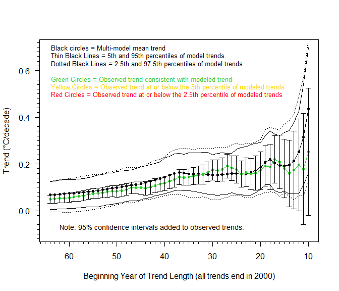

Note: To obtain these last two figures all you need to do is re-run the code, but assign a new end year as the fixed point for the regressions (e.g.`end_year <- c(2014, 2005, 2000)[2]` for 2005) at the top of the script.

[^1]: If you *really* can’t help yourself, click [here](http://rawgit.com/grantmcdermott/cmip5-models/master/cmip5_download/cmip5_download.html) for instructions on how to download and clean the CMIP5 ensemble data.